# Limpieza, transformación y normalización de datos

## 1.3 Normalización y escalado

En modelos basados en distancias (KNN, SVM) o en gradientes (regresión logística, redes neuronales), variables en escalas distintas distorsionan los resultados. La normalización pone todas en una escala común.

| Método | Fórmula | Cuándo usar |
| --- | --- | --- |
| Min-Max | $(x - x_{\min}) / (x_{\max} - x_{\min})$ | Rango [0,1] conocido; redes con sigmoide |
| Z-score | $(x - \bar{x}) / s$ | Distribución aproximadamente normal; PCA, SVM |
| L2 (por fila) | $\mathbf{x} / \\|\mathbf{x}\\|_2$ | Similitud coseno; NLP |

### Implementación

#### R

```r
titanic_num <- titanic_tmp |>
  select(age, fare, sibsp, parch) |>
  na.omit()

# Min-Max con mutate
titanic_num |>
  mutate(across(everything(),
                ~ (.x - min(.x)) / (max(.x) - min(.x)),
                .names = "{.col}_mm")) |>
  select(ends_with("_mm")) |>
  summarise(across(everything(), list(min = min, max = max)))
```

```
## # A tibble: 1 × 8
##   age_mm_min age_mm_max fare_mm_min fare_mm_max sibsp_mm_min sibsp_mm_max
##        <dbl>      <dbl>       <dbl>       <dbl>        <dbl>        <dbl>
## 1          0          1           0           1            0            1
## # ℹ 2 more variables: parch_mm_min <dbl>, parch_mm_max <dbl>
```

```r
# Z-score con across
titanic_num |>
  mutate(across(everything(),
                ~ (.x - mean(.x)) / sd(.x),
                .names = "{.col}_z")) |>
  select(ends_with("_z")) |>
  summarise(across(everything(),
                   list(media = ~ round(mean(.x), 4),
                        sd    = ~ round(sd(.x),   4))))
```

```
## # A tibble: 1 × 8
##   age_z_media age_z_sd fare_z_media fare_z_sd sibsp_z_media sibsp_z_sd
##         <dbl>    <dbl>        <dbl>     <dbl>         <dbl>      <dbl>
## 1           0        1            0         1             0          1
## # ℹ 2 more variables: parch_z_media <dbl>, parch_z_sd <dbl>
```

#### Python

```python
from sklearn.preprocessing import MinMaxScaler, StandardScaler, Normalizer
import pandas as pd

cols = ["age","fare","sibsp","parch"]
X = titanic[cols].dropna()

# Min-Max
X_mm  = pd.DataFrame(MinMaxScaler().fit_transform(X),  columns=[c+"_mm"  for c in cols])
# Z-score
X_std = pd.DataFrame(StandardScaler().fit_transform(X), columns=[c+"_std" for c in cols])
# L2
X_l2  = pd.DataFrame(Normalizer("l2").fit_transform(X), columns=[c+"_l2"  for c in cols])

print(X_mm.describe().round(3))   # min≈0, max≈1
print(X_std.describe().round(3))  # mean≈0, std=1
```

## 1.4 Reestructuración

Transformar la **forma** del data frame es tan importante como transformar su contenido. `tidyr` provee funciones para pasar entre formatos y para dividir o unir columnas.

### `pivot_longer()` y `pivot_wider()`

Transforman la **forma** del data frame sin modificar su contenido. Son las funciones inversas entre sí y reemplazan a las antiguas `gather()` y `spread()`.

**`pivot_longer(data, cols, names_to, values_to, ...)`**, ancho → largo: apila varias columnas en dos nuevas (nombres y valores), incrementando filas y reduciendo columnas.

| Parámetro | Descripción |
| --- | --- |
| `cols` | Columnas a apilar (tidy-select) |
| `names_to` | Nombre(s) de la columna que recibirá los nombres originales; `NA` descarta, `".value"` extrae nombres de columnas del propio valor |
| `values_to` | Nombre de la columna que recibirá los valores |
| `names_pattern` | Regex con grupos de captura para descomponer nombres compuestos en varias columnas |
| `names_sep` | Separador (string o posición numérica) para dividir nombres |
| `names_transform` | Lista de funciones para convertir los nombres a un tipo específico |
| `values_transform` | Lista de funciones para convertir los valores |
| `values_drop_na` | `TRUE` elimina filas donde el valor resultante es `NA` |
| `cols_vary` | `"fastest"` (defecto): agrupa por variable; `"slowest"`: agrupa por fila original |

**Retorna:** tibble largo con más filas y menos columnas.

**`pivot_wider(data, names_from, values_from, ...)`**, largo → ancho: expande filas en columnas, reduciendo filas e incrementando columnas.

| Parámetro | Descripción |
| --- | --- |
| `names_from` | Columna cuyos valores se convierten en nombres de columna |
| `values_from` | Columna cuyos valores llenan las celdas |
| `values_fill` | Valor para celdas sin observación (puede ser lista nombrada para múltiples columnas) |
| `values_fn` | Función de agregación cuando hay duplicados, sin ella genera list-columns |
| `names_glue` | Plantilla glue para personalizar nombres de columna resultantes |
| `names_vary` | `"fastest"` (defecto) o `"slowest"` cuando hay múltiples `values_from` |
| `unused_fn` | Función para resumir columnas no usadas en el pivot |

**Retorna:** tibble ancho con más columnas y menos filas.

> **No obvio 1:** `names_to = ".value"` en `pivot_longer` es el caso más potente, extrae nombres de columnas de salida directamente del patrón de los nombres de entrada.

> **No obvio 2:** si hay combinaciones duplicadas de `id_cols + names_from`, `pivot_wider` crea list-columns. Solucionarlo con `values_fn = list` (mantener como lista) o `values_fn = mean` (agregar).

> **No obvio 3:** `values_drop_na = TRUE` en `pivot_longer` elimina filas donde el valor sería `NA`, útil con datos dispersos.

#### R

```r
ventas <- tibble(
  pais   = c("Colombia","México","Perú"),
  `2022` = c(120, 340, 89),
  `2023` = c(145, 380, 102),
  `2024` = c(160, 410, 118)
)

# wide → long
ventas_long <- ventas |>
  pivot_longer(-pais, names_to = "anio", values_to = "ventas")
ventas_long
```

```
## # A tibble: 9 × 3
##   pais     anio  ventas
##   <chr>    <chr>  <dbl>
## 1 Colombia 2022     120
## 2 Colombia 2023     145
## 3 Colombia 2024     160
## 4 México   2022     340
## 5 México   2023     380
## 6 México   2024     410
## 7 Perú     2022      89
## 8 Perú     2023     102
## 9 Perú     2024     118
```

```r
# long → wide
ventas_long |>
  pivot_wider(names_from = anio, values_from = ventas)
```

```
## # A tibble: 3 × 4
##   pais     `2022` `2023` `2024`
##   <chr>     <dbl>  <dbl>  <dbl>
## 1 Colombia    120    145    160
## 2 México      340    380    410
## 3 Perú         89    102    118
```

```r
# names_pattern: descomponer nombres compuestos con regex
tibble(pais = "Colombia", Q1_2023 = 30, Q2_2023 = 35, Q1_2024 = 38) |>
  pivot_longer(-pais,
               names_to      = c("trimestre","anio"),
               names_pattern = "(.+)_(.+)")
```

```
## # A tibble: 3 × 4
##   pais     trimestre anio  value
##   <chr>    <chr>     <chr> <dbl>
## 1 Colombia Q1        2023     30
## 2 Colombia Q2        2023     35
## 3 Colombia Q1        2024     38
```

#### Python

```python
ventas = pd.DataFrame({
    "pais":  ["Colombia","México","Perú"],
    "2022": [120, 340, 89],
    "2023": [145, 380, 102],
    "2024": [160, 410, 118]
})

# wide → long (melt)
ventas_long = ventas.melt(id_vars="pais", var_name="anio", value_name="ventas")

# long → wide (pivot)
ventas_long.pivot(index="pais", columns="anio", values="ventas").reset_index()

# names_pattern → str.extract + melt
df = pd.DataFrame({"pais":["Colombia"],"Q1_2023":[30],"Q2_2023":[35],"Q1_2024":[38]})
df.melt(id_vars="pais").assign(
    trimestre = lambda d: d["variable"].str.extract(r"(.+)_\d+")[0],
    anio      = lambda d: d["variable"].str.extract(r".+_(\d+)")[0]
).drop(columns="variable")
```

### `separate()` y `unite()`

**`separate()`** divide una columna de texto en varias usando un delimitador o regex. **Está deprecada** en favor de las versiones modernas `separate_wider_delim()`, `separate_wider_regex()` y `separate_wider_position()`, que tienen mejores mensajes de error y control más fino.

**`unite()`** concatena varias columnas en una sola con un separador configurable.

**Parámetros de `separate()` (legado):**

| Parámetro | Descripción |
| --- | --- |
| `col` | Columna a dividir |
| `into` | Nombres de las nuevas columnas; `NA` descarta esa parte |
| `sep` | Regex o posiciones numéricas; defecto: `"[^[:alnum:]]+"` (cualquier no-alfanumérico) |
| `remove` | `TRUE` (defecto): elimina la columna original |
| `convert` | `TRUE`: detecta y convierte tipos automáticamente (útil para fechas, números) |
| `extra` | Qué hacer con piezas extra: `"warn"`, `"drop"`, `"merge"` |
| `fill` | Qué hacer con piezas faltantes: `"warn"`, `"right"`, `"left"` |

**Funciones modernas recomendadas:**

| Función | Cuándo usarla |
| --- | --- |
| `separate_wider_delim()` | Separador fijo (coma, guión, espacio) |
| `separate_wider_regex()` | Grupos de captura en regex |
| `separate_wider_position()` | Posiciones numéricas fijas |

> **No obvio:** `extra = "merge"` limita el número de divisiones a `length(into)`, equivale al parámetro `n` de `str_split_fixed()`. Sin él, piezas extra generan advertencia o se pierden silenciosamente.

#### R

```r
# separate(): dividir "apellido, título. nombre"
titanic_tmp |>
  separate(name, into = c("apellido", "resto"),
           sep = ", ", extra = "merge", fill = "right") |>
  select(apellido, resto) |>
  head(4)
```

```
## # A tibble: 4 × 2
##   apellido  resto
##   <chr>     <chr>
## 1 Graham    Mr. George Edward
## 2 Goldsmith Mr. Frank John
## 3 Fortune   Miss. Alice Elizabeth
## 4 Vestrom   Miss. Hulda Amanda Adolfina
```

```r
# unite(): combinar pclass y sex en una sola etiqueta
titanic_tmp |>
  unite("clase_sexo", pclass, sex, sep = "_") |>
  count(clase_sexo)
```

```
## # A tibble: 6 × 2
##   clase_sexo     n
##   <chr>      <int>
## 1 1_female     144
## 2 1_male       179
## 3 2_female     106
## 4 2_male       171
## 5 3_female     216
## 6 3_male       493
```

#### Python

```python
# separate → str.split() con expand=True
titanic[["apellido","resto"]] = (
    titanic["name"].str.split(", ", n=1, expand=True)
)
titanic[["apellido","resto"]].head(4)

# unite → str.cat() o astype(str) + "+"
titanic["clase_sexo"] = titanic["pclass"].astype(str) + "_" + titanic["sex"]
titanic["clase_sexo"].value_counts()
```

### `unnest()`

Cuando una columna contiene listas (resultado de `nest()` o de `fromJSON`), `unnest()` expande cada elemento en una fila independiente.

#### R

```r
# Crear un data frame con una columna de listas
df_anidado <- tibble(
  grupo   = c("A", "B"),
  valores = list(c(1, 2, 3), c(10, 20))
)
df_anidado
```

```
## # A tibble: 2 × 2
##   grupo valores
##   <chr> <list>
## 1 A     <dbl [3]>
## 2 B     <dbl [2]>
```

```r
# unnest: cada elemento de la lista se convierte en una fila
df_anidado |> unnest(valores)
```

```
## # A tibble: 5 × 2
##   grupo valores
##   <chr>   <dbl>
## 1 A           1
## 2 A           2
## 3 A           3
## 4 B          10
## 5 B          20
```

#### Python

```python
# unnest → explode()
df_anidado = pd.DataFrame({
    "grupo":   ["A",       "B"],
    "valores": [[1, 2, 3], [10, 20]]
})
df_anidado.explode("valores").reset_index(drop=True)
```

## 1.5 Iteración

Aplicar una función a cada elemento de una lista o vector es la operación central en pipelines de limpieza masiva. R ofrece dos paradigmas: la familia `apply` de base R y el ecosistema `purrr`.

### Familia `apply` de base R

| Función | Input | Output | Uso típico |
| --- | --- | --- | --- |
| `apply(X, MARGIN, FUN)` | matriz / array | vector o lista | estadísticas por fila (1) o columna (2) |
| `lapply(X, FUN)` | lista / vector | lista | transformar cada elemento; siempre lista |
| `sapply(X, FUN)` | lista / vector | vector / matriz | como `lapply` pero simplifica el resultado |
| `mapply(FUN, ...)` | múltiples vectores | vector / lista | `map2` de base R; itera sobre varios inputs |
| `tapply(X, INDEX, FUN)` | vector + factor | array | estadísticas por grupo |

**Ventajas:** no requieren paquetes externos, comportamiento conocido. **Desventajas:** `sapply` silencia errores de tipo (simplifica sin avisar), lo que produce bugs difíciles de detectar. `lapply` siempre devuelve lista aunque el resultado sea un escalar.

#### R

```r
mat <- matrix(1:12, nrow = 3)

# apply: media por fila (MARGIN=1) y por columna (MARGIN=2)
apply(mat, 1, mean)
```

```
## [1] 5.5 6.5 7.5
```

```r
apply(mat, 2, sum)
```

```
## [1]  6 15 24 33
```

```r
# lapply: devuelve siempre lista
lapply(titanic_tmp[, c("age","fare")], function(x) round(mean(x, na.rm=TRUE), 2))
```

```
## $age
## [1] 29.88
##
## $fare
## [1] 33.3
```

```r
# sapply: simplifica a vector cuando es posible
sapply(titanic_tmp[, c("age","fare","sibsp")],
       function(x) round(mean(x, na.rm=TRUE), 2))
```

```
##   age  fare sibsp
## 29.88 33.30  0.50
```

```r
# mapply: dos vectores en paralelo
mapply(function(x, y) x + y, 1:4, 5:8)
```

```
## [1]  6  8 10 12
```

```r
# tapply: media de fare por pclass
tapply(titanic_tmp$fare, titanic_tmp$pclass, mean, na.rm = TRUE)
```

```
##        1        2        3
## 87.50899 21.17920 13.30289
```

#### Python

```python
import numpy as np

mat = np.arange(1,13).reshape(3,4)

# apply(MARGIN=1) → axis=1 ; apply(MARGIN=2) → axis=0
np.mean(mat, axis=1)   # media por fila
np.sum(mat, axis=0)    # suma por columna

# lapply → list comprehension
[round(titanic[c].mean(), 2) for c in ["age","fare"]]

# sapply → dict comprehension
{c: round(titanic[c].mean(), 2) for c in ["age","fare","sibsp"]}

# mapply → zip + list comprehension
[x + y for x, y in zip(range(1,5), range(5,9))]

# tapply → groupby
titanic.groupby("pclass")["fare"].mean().round(2)
```

### `purrr::map` y familia

`purrr` es el reemplazo funcional y **tipado** de la familia `apply`. Su ventaja principal es que el tipo de retorno es **explícito y verificado**, si el resultado no coincide con el tipo esperado, falla con un mensaje claro en lugar de simplificar silenciosamente.

**Variantes y retornos:**

| Función | Retorna | Equivale a |
| --- | --- | --- |
| `map(.x, .f)` | lista | `lapply` |
| `map_vec(.x, .f)` | vector (tipo inferido automáticamente) | `sapply` sin sorpresas de tipo |
| `map_dbl / map_int / map_chr / map_lgl` | vector del tipo declarado | `sapply` con tipo forzado |
| `map2(.x, .y, .f)` | lista, itera dos inputs en paralelo | `mapply` con 2 vectores |
| `pmap(.l, .f)` | lista, itera N inputs en paralelo | `mapply` con N vectores |
| `walk(.x, .f)` | `.x` invisible, solo efectos secundarios | bucle `for` sin retorno |
| `map() \|> list_rbind()` | tibble apilado por filas | `map_df()` / `map_dfr()` *(superseded)* |
| `map() \|> list_cbind()` | tibble apilado por columnas | `map_dfc()` *(superseded)* |

**Parámetros de `map()`:**

| Parámetro | Descripción |
| --- | --- |
| `.x` | Lista o vector atómico de entrada |
| `.f` | Función, lambda `\(x) expr`, fórmula `~ expr(.x)`, o string `"nombre_función"` |
| `.progress` | `TRUE` o string: muestra barra de progreso *(purrr ≥ 1.0)* |

**Retorna:** lista de la misma longitud que `.x`; las variantes tipadas devuelven vectores del tipo correspondiente.

> **Cambio purrr 1.0:** `map_df()`, `map_dfr()` y `map_dfc()` fueron marcados *superseded*. La forma canónica moderna es `map() |> list_rbind()` (apilar filas) o `map() |> list_cbind()` (apilar columnas), usa `vctrs` internamente con mejor manejo de tipos.

> **No obvio 1:** `.f` puede ser un entero o string para extracción: `map(lista, "nombre")` extrae el elemento `"nombre"` de cada sublista, equivale a `lapply(lista,`[[`, "nombre")`.

> **No obvio 2:** `pmap()` recibe una lista de vectores del mismo largo; los elementos se pasan a `.f` por posición o por nombre si la lista está nombrada.

#### R

```r
# map básico → lista
titanic_tmp |>
  select(age, fare, sibsp) |>
  map(~ mean(.x, na.rm = TRUE))
```

```
## $age
## [1] 29.88113
##
## $fare
## [1] 33.29548
##
## $sibsp
## [1] 0.4988541
```

```r
# map_dbl → vector numérico (falla si no es numérico)
titanic_tmp |>
  select(age, fare, sibsp) |>
  map_dbl(~ mean(.x, na.rm = TRUE))
```

```
##        age       fare      sibsp
## 29.8811345 33.2954793  0.4988541
```

```r
# Forma moderna de map_df: map() + list_rbind()
titanic_tmp |>
  select(age, fare, sibsp, parch) |>
  map(~ tibble(
    media   = round(mean(.x, na.rm = TRUE), 2),
    mediana = round(median(.x, na.rm = TRUE), 2),
    sd      = round(sd(.x,   na.rm = TRUE), 2)
  )) |>
  list_rbind(names_to = "variable") |>
  mostrar_tabla(caption = "Estadísticas con map + list_rbind")
```

Estadísticas con map + list_rbind

| variable | media | mediana | sd |
| --- | --- | --- | --- |
| age | 29.88 | 28.00 | 14.41 |
| fare | 33.30 | 14.45 | 51.76 |
| sibsp | 0.50 | 0.00 | 1.04 |
| parch | 0.39 | 0.00 | 0.87 |

```r
# map2: iterar sobre dos vectores en paralelo
pesos   <- list(0.3, 0.5, 0.2)
valores <- list(c(10, 20), c(5, 15), c(8, 12))
map2_dbl(pesos, valores, ~ .x * mean(.y))
```

```
## [1] 4.5 5.0 2.0
```

```r
# walk: efectos secundarios (sin retorno visible)
list(titanic = titanic_tmp,
     moviles = read_csv("../../data/mobile_data.csv", show_col_types = FALSE)) |>
  walk(~ cat("Filas:", nrow(.x), "| Cols:", ncol(.x), "\n"))
```

```
## Filas: 1309 | Cols: 16
## Filas: 3000 | Cols: 21
```

#### Python

```python
# map → list / dict comprehension
cols = ["age","fare","sibsp"]
{c: titanic[c].mean() for c in cols}                    # map_dbl

# list_rbind → pd.concat
pd.concat([
    pd.DataFrame({"media":   [titanic[c].mean()],
                  "mediana": [titanic[c].median()],
                  "sd":      [titanic[c].std()]},
                 index=[c])
    for c in ["age","fare","sibsp","parch"]
]).rename_axis("variable").reset_index()

# map2 → zip
pesos  = [0.3, 0.5, 0.2]
valores = [[10,20],[5,15],[8,12]]
[p * pd.Series(v).mean() for p, v in zip(pesos, valores)]

# walk → bucle for sin retorno
for nombre, df in {"titanic": titanic}.items():
    print(f"Filas: {df.shape[0]} | Cols: {df.shape[1]}")
```

## 1.6 Manejo de JSON

Los datos de APIs web (redes sociales, catastro, DANE) llegan en JSON. `jsonlite` convierte entre JSON y estructuras R nativas.

| Función | Descripción |
| --- | --- |
| `fromJSON(txt)` | JSON → lista / data frame |
| `toJSON(x)` | lista / data frame → JSON |
| `flatten(x)` | aplana una lista anidada |
| `read_json(path)` | lee un archivo `.json` directamente |

### R

```r
library(jsonlite)

# JSON → data frame (fromJSON infiere la estructura)
json_str <- '[
  {"nombre":"Ana","edad":28,"ciudad":"Bogotá"},
  {"nombre":"Luis","edad":35,"ciudad":"Medellín"}
]'

personas <- fromJSON(json_str)
class(personas); personas
```

```
## [1] "data.frame"
```

```
##   nombre edad   ciudad
## 1    Ana   28   Bogotá
## 2   Luis   35 Medellín
```

```r
# data frame → JSON
toJSON(personas, pretty = TRUE, auto_unbox = TRUE)
```

```
## [
##   {
##     "nombre": "Ana",
##     "edad": 28,
##     "ciudad": "Bogotá"
##   },
##   {
##     "nombre": "Luis",
##     "edad": 35,
##     "ciudad": "Medellín"
##   }
## ]
```

```r
# JSON anidado → flatten aplana un nivel
json_anidado <- '{"nombre":"Ana","direccion":{"ciudad":"Bogotá","barrio":"Chapinero"}}'
registro <- fromJSON(json_anidado)
str(registro)
```

```
## List of 2
##  $ nombre   : chr "Ana"
##  $ direccion:List of 2
##   ..$ ciudad: chr "Bogotá"
##   ..$ barrio: chr "Chapinero"
```

```r
flatten(as.data.frame(registro))   # aplana listas anidadas en columnas
```

```
##   nombre direccion.ciudad direccion.barrio
## 1    Ana           Bogotá        Chapinero
```

```r
# purrr + fromJSON: leer múltiples archivos JSON
# archivos <- list.files("data/", pattern="\\.json$", full.names=TRUE)
# datos <- map(archivos, fromJSON) |> list_rbind()
```

### Python

```python
import json, pandas as pd

# JSON → dict / DataFrame
json_str = '[{"nombre":"Ana","edad":28,"ciudad":"Bogotá"},{"nombre":"Luis","edad":35,"ciudad":"Medellín"}]'
personas = pd.read_json(json_str)
personas

# DataFrame → JSON
print(personas.to_json(orient="records", force_ascii=False, indent=2))

# JSON anidado → pd.json_normalize() aplana automáticamente
import json
registro = json.loads('{"nombre":"Ana","direccion":{"ciudad":"Bogotá","barrio":"Chapinero"}}')
pd.json_normalize(registro)

# Múltiples archivos JSON
# import glob
# datos = pd.concat([pd.read_json(f) for f in glob.glob("data/*.json")])
```

## 1.7 Limpieza de texto

Las variables de texto son frecuentes en datos reales (nombres, categorías, descripciones). `stringr` provee una interfaz **uniforme y predecible** sobre las expresiones regulares de R: todas las funciones empiezan con `str_`, el **primer argumento siempre es el vector de texto** y los patrones son siempre expresiones regulares (salvo que se use `fixed()`).

**Detección:**

| Función | Parámetros clave | Retorna | No obvio |
| --- | --- | --- | --- |
| `str_detect(x, pat)` | `negate = TRUE` invierte | vector lógico | Usable directamente en `filter()` |
| `str_starts(x, pat)` | — | vector lógico | Anclado al inicio (más rápido que `str_detect("^pat")`) |
| `str_ends(x, pat)` | — | vector lógico | Anclado al final |
| `str_count(x, pat)` | — | entero | Cuenta ocurrencias por elemento, no por vector |

**Extracción:**

| Función | Parámetros clave | Retorna | No obvio |
| --- | --- | --- | --- |
| `str_extract(x, pat)` | — | carácter (NA si no hay) | Extrae **primera** coincidencia; `NA` si no hay match |
| `str_extract_all(x, pat)` | `simplify = TRUE` → matriz | lista de vectores | Con `simplify = TRUE` devuelve matriz |
| `str_sub(x, start, end)` | posiciones numéricas | carácter | Negativas cuentan desde el final: `str_sub(x, -3, -1)` |
| `str_match(x, pat)` | grupos de captura `()` | matriz | Columna 1 = match completo; siguientes = grupos |

**Modificación:**

| Función | Parámetros clave | Retorna | No obvio |
| --- | --- | --- | --- |
| `str_replace(x, pat, rep)` | `rep` puede referenciar grupos: `"\\1"` | carácter | Solo reemplaza la **primera** coincidencia |
| `str_replace_all(x, pat, rep)` | `rep` puede ser vector nombrado para múltiples reemplazos simultáneos | carácter | `str_replace_all(x, c("a"="A","b"="B"))` aplica todo a la vez |
| `str_remove(x, pat)` | — | carácter | Atajo de `str_replace(x, pat, "")` |
| `str_trim(x, side)` | `side`: `"both"`, `"left"`, `"right"` | carácter | Solo elimina espacios U+0020; no otros espacios Unicode |
| `str_squish(x)` | — | carácter | Equivale a `str_trim` + colapsar espacios internos múltiples |
| `str_to_lower/upper/title(x)` | `locale` para idiomas con reglas especiales | carácter | `str_to_title` capitaliza **cada** palabra |
| `str_pad(x, width, side, pad)` | `pad = " "` por defecto | carácter | Útil para IDs de longitud fija |
| `str_glue(...)` | sintaxis `{variable}` | carácter | Equivale a f-strings de Python; evalúa R en `{}` |

**División:**

| Función | Parámetros clave | Retorna | No obvio |
| --- | --- | --- | --- |
| `str_split(x, pat, n)` | `n` limita el número de piezas | lista de vectores | `simplify = TRUE` devuelve matriz |
| `str_split_fixed(x, pat, n)` | `n` es obligatorio | matriz de caracteres | Siempre `n` columnas; rellena con `""` si faltan piezas |

### R

```r
library(stringr)

nombres <- c("  Ana Pérez ", "LUIS garcía", "maría RODRÍGUEZ  ")

# Limpiar espacios y normalizar mayúsculas
nombres_limpios <- nombres |>
  str_trim() |>
  str_squish() |>
  str_to_title()
nombres_limpios
```

```
## [1] "Ana Pérez"       "Luis García"     "María Rodríguez"
```

```r
# str_detect: filtrar pasajeros con "Mrs" en el nombre
titanic_tmp |>
  filter(str_detect(name, "Mrs\\.")) |>
  nrow()
```

```
## [1] 197
```

```r
# str_extract: extraer el título social
titanic_tmp |>
  mutate(titulo = str_extract(name, "(?<=, )[A-Za-z]+(?=\\.)")) |>
  count(titulo, sort = TRUE) |>
  head(6)
```

```
## # A tibble: 6 × 2
##   titulo     n
##   <chr>  <int>
## 1 Mr       757
## 2 Miss     260
## 3 Mrs      197
## 4 Master    61
## 5 Dr         8
## 6 Rev        8
```

```r
# str_replace_all: limpiar caracteres especiales de una columna
titanic_tmp |>
  mutate(name_clean = str_replace_all(name, "[^A-Za-z ]", "")) |>
  select(name, name_clean) |>
  head(4)
```

```
## # A tibble: 4 × 2
##   name                                 name_clean
##   <chr>                                <chr>
## 1 Graham, Mr. George Edward            Graham Mr George Edward
## 2 Goldsmith, Mr. Frank John            Goldsmith Mr Frank John
## 3 Fortune, Miss. Alice Elizabeth       Fortune Miss Alice Elizabeth
## 4 Vestrom, Miss. Hulda Amanda Adolfina Vestrom Miss Hulda Amanda Adolfina
```

```r
# str_glue: interpolación (como f-strings de Python)
edad <- 28; ciudad <- "Bogotá"
str_glue("El estudiante tiene {edad} años y vive en {ciudad}.")
```

```
## El estudiante tiene 28 años y vive en Bogotá.
```

### Python

```python
import re

nombres = ["  Ana Pérez ", "LUIS garcía", "maría RODRÍGUEZ  "]

# str_trim + str_squish + str_to_title
[n.strip().title() for n in nombres]

# str_detect → str.contains()
titanic[titanic["name"].str.contains(r"Mrs\.", na=False)].shape[0]

# str_extract → str.extract()
titanic["titulo"] = titanic["name"].str.extract(r",\s+([A-Za-z]+)\.")
titanic["titulo"].value_counts().head(6)

# str_replace_all → str.replace() con regex
titanic["name_clean"] = titanic["name"].str.replace(r"[^A-Za-z ]", "", regex=True)
titanic[["name","name_clean"]].head(4)

# str_glue → f-string
edad, ciudad = 28, "Bogotá"
f"El estudiante tiene {edad} años y vive en {ciudad}."
```

## 1.8 Vectorización: por qué importa en preprocesamiento

**Vectorizar** significa aplicar una operación a todos los elementos de un vector simultáneamente, sin un bucle `for` explícito. En R, casi todas las operaciones son vectorizadas por diseño.

**Ventajas en limpieza y transformación:**

| Ventaja | Explicación |
| --- | --- |
| **Velocidad** | Las operaciones vectorizadas se ejecutan en C/Fortran internamente, no en R interpretado. |
| **Legibilidad** | `x * 2` es más claro que `for (i in seq_along(x)) x[i] <- x[i] * 2`. |
| **Integración con `dplyr`** | `mutate`, `filter` y `across` esperan expresiones vectorizadas. |
| **Menos errores** | No hay índices que gestionar ni acumuladores que inicializar. |

**Cuándo un bucle `for` sí es necesario:**

- Cuando cada iteración depende del resultado de la anterior (ej. simulaciones, imputación secuencial).
- Cuando la función que se quiere aplicar no acepta vectores (entonces usar `purrr::map`).

### R

```r
# NO vectorizado (lento, verboso)
x <- titanic_tmp$fare
resultado_loop <- numeric(length(x))
for (i in seq_along(x)) {
  resultado_loop[i] <- if (!is.na(x[i])) log1p(x[i]) else NA
}

# Vectorizado (rápido, conciso)
resultado_vec <- log1p(x)

# ¿Son equivalentes?
all(round(resultado_loop, 8) == round(resultado_vec, 8), na.rm = TRUE)
```

```
## [1] TRUE
```

```r
# Benchmark simplificado
system.time(for (i in seq_along(x)) resultado_loop[i] <- log1p(x[i]))
```

```
##    user  system elapsed
##   0.001   0.000   0.002
```

```r
system.time(log1p(x))
```

```
##    user  system elapsed
##       0       0       0
```

```r
# across() vectoriza sobre columnas — lo opuesto a un bucle de columnas
titanic_tmp |>
  mutate(across(c(age, fare, sibsp, parch),
                ~ (.x - min(.x, na.rm=TRUE)) / (max(.x, na.rm=TRUE) - min(.x, na.rm=TRUE)),
                .names = "{.col}_mm")) |>
  select(ends_with("_mm")) |>
  head(3)
```

```
## # A tibble: 3 × 4
##   age_mm fare_mm sibsp_mm parch_mm
##    <dbl>   <dbl>    <dbl>    <dbl>
## 1  0.474  0.300     0        0.111
## 2  0.411  0.0401    0.125    0.111
## 3  0.299  0.513     0.375    0.222
```

### Python

```python
import numpy as np, time

x = titanic["fare"].values

# NO vectorizado
inicio = time.time()
res_loop = [np.log1p(v) if not np.isnan(v) else np.nan for v in x]
print(f"Bucle: {time.time()-inicio:.4f}s")

# Vectorizado con numpy
inicio = time.time()
res_vec = np.log1p(x)
print(f"Vectorizado: {time.time()-inicio:.4f}s")

# across() → apply sobre columnas numéricas (también vectorizado internamente)
cols = ["age","fare","sibsp","parch"]
X = titanic[cols].copy()
X_mm = (X - X.min()) / (X.max() - X.min())
X_mm.columns = [c+"_mm" for c in cols]
X_mm.head(3)
```

# 2. Exploración inicial: diagnóstico de calidad

Antes de limpiar, hay que **entender el estado real** del dataset. El principio es: *nunca limpies a ciegas*.

```r
titanic  <- read_csv("../../data/titanic.csv",      show_col_types = FALSE)
adult    <- read_csv("../../data/adult.csv",         show_col_types = FALSE)
precios  <- read_csv("../../data/house_prices.csv",  show_col_types = FALSE)
moviles  <- read_csv("../../data/mobile_data.csv",   show_col_types = FALSE)

cat("titanic :", nrow(titanic),  "×", ncol(titanic),  "\n")
```

```
## titanic : 1309 × 16
```

```r
cat("adult   :", nrow(adult),    "×", ncol(adult),    "\n")
```

```
## adult   : 32561 × 15
```

```r
cat("precios :", nrow(precios),  "×", ncol(precios),  "\n")
```

```
## precios : 2919 × 81
```

```r
cat("moviles :", nrow(moviles),  "×", ncol(moviles),  "\n")
```

```
## moviles : 3000 × 21
```

## 2.1 `glimpse` y resumen rápido

```r
glimpse(titanic)
```

```
## Rows: 1,309
## Columns: 16
## $ id        <dbl> 0, 1, 2, 3, 4, 5, 6, 7, 8, 9, 10, 11, 12, 13, 14, 15, 16, 17…
## $ index     <dbl> 138, 821, 111, 1279, 403, 657, 706, 219, 112, 967, 151, 46, …
## $ pclass    <dbl> 1, 3, 1, 3, 2, 3, 3, 1, 1, 3, 1, 1, 2, 3, 3, 1, 3, 3, 3, 3, …
## $ survived  <dbl> 0, 0, 1, 0, 0, 1, 0, 1, 1, 0, 1, 0, 0, 1, 0, 1, 0, 0, 0, 1, …
## $ name      <chr> "Graham, Mr. George Edward", "Goldsmith, Mr. Frank John", "F…
## $ sex       <chr> "male", "male", "female", "female", "male", "female", "femal…
## $ age       <dbl> 38.00, 33.00, 24.00, 14.00, 23.00, 0.75, NA, NA, 28.00, 45.0…
## $ sibsp     <dbl> 0, 1, 3, 0, 0, 2, 1, 0, 3, 0, 0, 0, 0, 1, 0, 0, 1, 0, 0, 0, …
## $ parch     <dbl> 1, 1, 2, 0, 0, 1, 0, 0, 2, 0, 0, 0, 0, 0, 0, 0, 1, 0, 0, 2, …
## $ ticket    <chr> "PC 17582", "363291", "19950", "350406", "29751", "2666", "2…
## $ fare      <dbl> 153.4625, 20.5250, 263.0000, 7.8542, 13.0000, 19.2583, 14.45…
## $ cabin     <chr> "C91", NA, "C23 C25 C27", NA, NA, NA, NA, NA, "C23 C25 C27",…
## $ embarked  <chr> "S", "S", "S", "S", "S", "C", "C", "C", "S", "S", "C", "S", …
## $ boat      <chr> NA, NA, "10", NA, NA, "C", NA, "7", "10", NA, "3", NA, NA, N…
## $ body      <dbl> 147, NA, NA, NA, NA, NA, NA, NA, NA, NA, NA, NA, NA, NA, NA,…
## $ home.dest <chr> "Winnipeg, MB", "Strood, Kent, England Detroit, MI", "Winnip…
```

```r
summary(titanic[, c("age", "fare", "pclass", "survived", "sex", "embarked")])
```

```
##       age               fare             pclass         survived
##  Min.   : 0.1667   Min.   :  0.000   Min.   :1.000   Min.   :0.0000
##  1st Qu.:21.0000   1st Qu.:  7.896   1st Qu.:2.000   1st Qu.:0.0000
##  Median :28.0000   Median : 14.454   Median :3.000   Median :0.0000
##  Mean   :29.8811   Mean   : 33.295   Mean   :2.295   Mean   :0.4133
##  3rd Qu.:39.0000   3rd Qu.: 31.275   3rd Qu.:3.000   3rd Qu.:1.0000
##  Max.   :80.0000   Max.   :512.329   Max.   :3.000   Max.   :1.0000
##  NA's   :263       NA's   :1
##      sex              embarked
##  Length:1309        Length:1309
##  Class :character   Class :character
##  Mode  :character   Mode  :character
##
##
##
##
```

## 2.2 Mapa de valores faltantes

La función `purrr::map_df` permite aplicar la misma operación a cada columna de forma declarativa:

```r
resumen_na <- titanic |>
  map_df(~ sum(is.na(.x))) |>
  pivot_longer(everything(), names_to = "columna", values_to = "n_na") |>
  mutate(
    pct_na   = round(n_na / nrow(titanic) * 100, 1),
    tiene_na = n_na > 0
  ) |>
  filter(tiene_na) |>
  arrange(desc(pct_na))

mostrar_tabla(resumen_na, caption = "Valores faltantes por columna — Titanic")
```

Valores faltantes por columna — Titanic

| columna | n_na | pct_na | tiene_na |
| --- | --- | --- | --- |
| body | 1188 | 90.8 | TRUE |
| cabin | 1014 | 77.5 | TRUE |
| boat | 823 | 62.9 | TRUE |
| home.dest | 564 | 43.1 | TRUE |
| age | 263 | 20.1 | TRUE |
| embarked | 2 | 0.2 | TRUE |
| fare | 1 | 0.1 | TRUE |

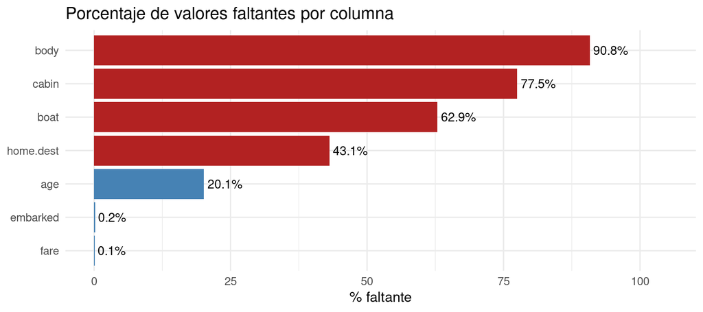

```r
resumen_na |>
  ggplot(aes(x = reorder(columna, pct_na), y = pct_na, fill = pct_na > 30)) +
  geom_col() +
  geom_text(aes(label = paste0(pct_na, "%")), hjust = -0.1, size = 4) +
  coord_flip() +
  scale_fill_manual(values = c("steelblue", "firebrick"), guide = "none") +
  scale_y_continuous(limits = c(0, 105)) +
  labs(
    title   = "Porcentaje de valores faltantes por columna",
    x       = NULL, y     = "% faltante"
  ) +
  theme_minimal(base_size = 13)
```

> **Regla práctica:** columnas con > 50 % de NA raramente aportan valor y es mejor eliminarlas. Entre 5–50 % hay que decidir entre imputar o eliminar filas.

## 2.3 Diagnóstico con `purrr::map`

`purrr` permite inspeccionar tipo y cardinalidad de cada columna en una sola pasada:

```r
diagnostico <- titanic |>
  map_df(~ tibble(
    tipo        = class(.x)[1],
    n_unicos    = n_distinct(.x, na.rm = TRUE),
    n_na        = sum(is.na(.x)),
    ejemplo     = as.character(.x[!is.na(.x)][1])
  ), .id = "columna")

mostrar_tabla(diagnostico, n = 16, caption = "Diagnóstico completo de columnas")
```

Diagnóstico completo de columnas

| columna | tipo | n_unicos | n_na | ejemplo |
| --- | --- | --- | --- | --- |
| id | numeric | 916 | 0 | 0 |
| index | numeric | 1309 | 0 | 138 |
| pclass | numeric | 3 | 0 | 1 |
| survived | numeric | 2 | 0 | 0 |
| name | character | 1307 | 0 | Graham, Mr. George Edward |
| sex | character | 2 | 0 | male |
| age | numeric | 98 | 263 | 38 |
| sibsp | numeric | 7 | 0 | 0 |
| parch | numeric | 8 | 0 | 1 |
| ticket | character | 929 | 0 | PC 17582 |
| fare | numeric | 281 | 1 | 153.4625 |
| cabin | character | 186 | 1014 | C91 |
| embarked | character | 3 | 2 | S |
| boat | character | 27 | 823 | 10 |
| body | numeric | 121 | 1188 | 147 |
| home.dest | character | 369 | 564 | Winnipeg, MB |

# 3. Manejo de valores faltantes

## 3.1 Estrategias disponibles

| Estrategia | Cuándo usarla | Riesgo |
| --- | --- | --- |
| Eliminar filas (`drop_na`) | Pocos NA (<5 %), datos MAR | Pérdida de muestra |
| Eliminar columnas | NA > 50 % o variable irrelevante | Pérdida de información |
| Imputar con media/mediana | Variables numéricas, distribución simétrica/asimétrica | Reduce varianza |
| Imputar con moda | Variables categóricas | Sesga distribución |
| Imputar con modelo | Alto % NA, relación con otras vars | Complejidad |

## 3.2 Eliminar columnas con exceso de NA

```r
umbral_cols <- 0.50  # eliminar si > 50% NA

titanic_limpio <- titanic |>
  select(where(~ mean(is.na(.x)) <= umbral_cols))

cat("Columnas antes:", ncol(titanic), "\n")
```

```
## Columnas antes: 16
```

```r
cat("Columnas después:", ncol(titanic_limpio), "\n")
```

```
## Columnas después: 13
```

```r
cat("Eliminadas:", setdiff(names(titanic), names(titanic_limpio)), "\n")
```

```
## Eliminadas: cabin boat body
```

## 3.3 Imputación con mediana (variables numéricas)

La mediana es más robusta que la media cuando hay outliers:

```r
titanic_limpio <- titanic_limpio |>
  mutate(
    age_imp = if_else(
      is.na(age),
      median(age, na.rm = TRUE),
      age
    )
  )

cat("NA en age antes :", sum(is.na(titanic_limpio$age)), "\n")
```

```
## NA en age antes : 263
```

```r
cat("NA en age después:", sum(is.na(titanic_limpio$age_imp)), "\n")
```

```
## NA en age después: 0
```

```r
cat("Mediana usada   :", median(titanic_limpio$age, na.rm = TRUE), "\n")
```

```
## Mediana usada   : 28
```

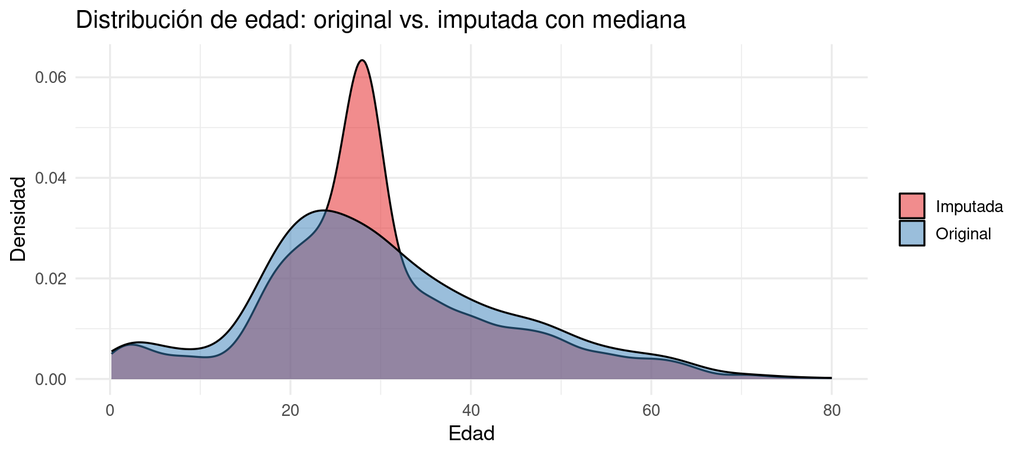

```r
bind_rows(
  tibble(valor = titanic_limpio$age[!is.na(titanic_limpio$age)],     tipo = "Original"),
  tibble(valor = titanic_limpio$age_imp,                              tipo = "Imputada")
) |>
  ggplot(aes(x = valor, fill = tipo)) +
  geom_density(alpha = 0.5) +
  scale_fill_brewer(palette = "Set1") +
  labs(title = "Distribución de edad: original vs. imputada con mediana",
       x = "Edad", y = "Densidad", fill = NULL) +
  theme_minimal(base_size = 13)
```

## 3.4 Imputación por grupo (más precisa)

Imputar la edad por el título social reduce el sesgo, ya que `Master` (niños) y `Mr` (adultos) tienen distribuciones muy distintas:

```r
titanic_limpio <- titanic_limpio |>
  mutate(titulo = str_extract(name, "(?<=, )[A-Za-z]+(?=\\.)")) |>
  group_by(titulo) |>
  mutate(
    age_grupo = if_else(
      is.na(age),
      median(age, na.rm = TRUE),
      age
    )
  ) |>
  ungroup()

titanic_limpio |>
  group_by(titulo) |>
  summarise(
    mediana_grupo = round(median(age, na.rm = TRUE), 1),
    n_imputados   = sum(is.na(age)),
    .groups = "drop"
  ) |>
  filter(!is.na(mediana_grupo)) |>
  arrange(desc(n_imputados)) |>
  mostrar_tabla(caption = "Mediana de edad por título (usada para imputar)")
```

Mediana de edad por título (usada para imputar)

| titulo | mediana_grupo | n_imputados |
| --- | --- | --- |
| Mr | 29.0 | 176 |
| Miss | 22.0 | 50 |
| Mrs | 35.5 | 27 |
| Master | 4.0 | 8 |
| Dr | 49.0 | 1 |
| Ms | 28.0 | 1 |
| Capt | 70.0 | 0 |
| Col | 54.5 | 0 |
| Don | 40.0 | 0 |
| Dona | 39.0 | 0 |

## 3.5 Imputación de categóricas con la moda

```r
moda <- function(x) {
  ux <- unique(x[!is.na(x)])
  ux[which.max(tabulate(match(x, ux)))]
}

titanic_limpio <- titanic_limpio |>
  mutate(
    embarked_imp = if_else(is.na(embarked), moda(embarked), embarked)
  )

cat("NA en embarked antes :", sum(is.na(titanic_limpio$embarked)), "\n")
```

```
## NA en embarked antes : 2
```

```r
cat("NA en embarked después:", sum(is.na(titanic_limpio$embarked_imp)), "\n")
```

```
## NA en embarked después: 0
```

```r
cat("Moda usada            :", moda(titanic_limpio$embarked), "\n")
```

```
## Moda usada            : S
```

## 3.6 `tidyr::fill`

Imputación por propagación (series de tiempo / datos ordenados)

```r
ventas_sim <- tibble(
  mes    = month.abb[1:8],
  ventas = c(120, NA, NA, 145, NA, 160, NA, 175)
)

ventas_sim |>
  mutate(
    fill_adelante = fill(pick(ventas), ventas, .direction = "down")$ventas,
    fill_atras    = fill(pick(ventas), ventas, .direction = "up")$ventas
  ) |>
  mostrar_tabla(caption = "tidyr::fill — propagación hacia adelante y hacia atrás")
```

tidyr::fill — propagación hacia adelante y hacia atrás

| mes | ventas | fill_adelante | fill_atras |
| --- | --- | --- | --- |
| Jan | 120 | 120 | 120 |
| Feb | NA | 120 | 145 |
| Mar | NA | 120 | 145 |
| Apr | 145 | 145 | 145 |
| May | NA | 145 | 160 |
| Jun | 160 | 160 | 160 |
| Jul | NA | 160 | 175 |
| Aug | 175 | 175 | 175 |

# 4. Detección y tratamiento de outliers

Los valores atípicos pueden ser **errores de medición** o **casos legítimos pero extremos**. Es crucial distinguirlos.

## 4.1 Método IQR (rango intercuartílico)

El criterio de Tukey define outliers como observaciones fuera de `[Q1 − 1.5·IQR, Q3 + 1.5·IQR]`:

```r
detectar_outliers_iqr <- function(x, k = 1.5) {
  q1  <- quantile(x, 0.25, na.rm = TRUE)
  q3  <- quantile(x, 0.75, na.rm = TRUE)
  iqr <- q3 - q1
  x < (q1 - k * iqr) | x > (q3 + k * iqr)
}

titanic_limpio <- titanic_limpio |>
  mutate(
    outlier_fare = detectar_outliers_iqr(fare),
    outlier_age  = detectar_outliers_iqr(age_imp)
  )

cat("Outliers en fare:", sum(titanic_limpio$outlier_fare, na.rm = TRUE), "\n")
```

```
## Outliers en fare: 171
```

```r
cat("Outliers en age :", sum(titanic_limpio$outlier_age,  na.rm = TRUE), "\n")
```

```
## Outliers en age : 101
```

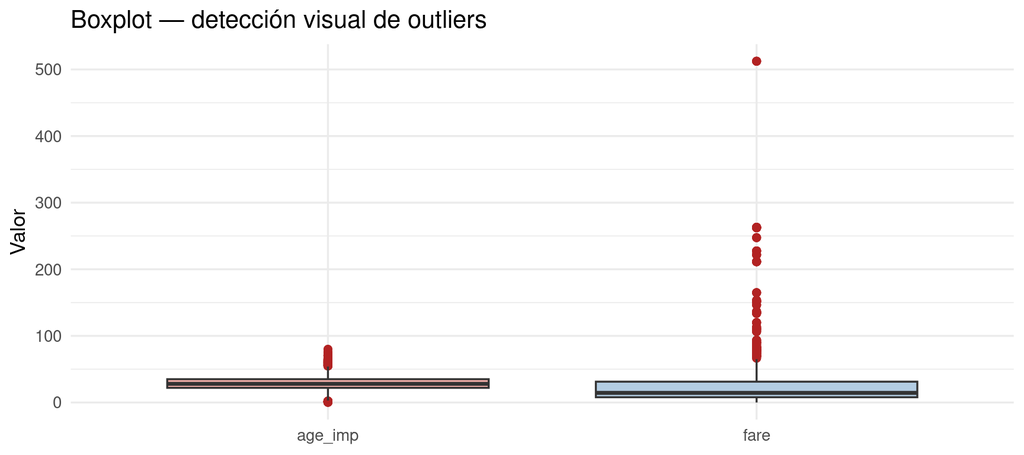

```r
titanic_limpio |>
  select(fare, age_imp) |>
  pivot_longer(everything(), names_to = "variable", values_to = "valor") |>
  ggplot(aes(x = variable, y = valor, fill = variable)) +
  geom_boxplot(outlier.colour = "firebrick", outlier.size = 2) +
  scale_fill_brewer(palette = "Pastel1", guide = "none") +
  labs(title = "Boxplot — detección visual de outliers", x = NULL, y = "Valor") +
  theme_minimal(base_size = 13)
```

## 4.2 Método Z-score

Útil cuando la distribución es aproximadamente normal. Outlier si `|z| > 3`:

```r
zscore <- function(x) (x - mean(x, na.rm = TRUE)) / sd(x, na.rm = TRUE)

titanic_limpio <- titanic_limpio |>
  mutate(
    z_fare = zscore(fare),
    z_age  = zscore(age_imp),
    outlier_z_fare = abs(z_fare) > 3
  )

cat("Outliers por Z-score (|z|>3) en fare:",
    sum(titanic_limpio$outlier_z_fare, na.rm = TRUE), "\n")
```

```
## Outliers por Z-score (|z|>3) en fare: 38
```

```r
titanic_limpio |>
  filter(outlier_z_fare) |>
  select(name, pclass, fare, z_fare) |>
  arrange(desc(fare)) |>
  mostrar_tabla(caption = "Tarifas extremas por Z-score")
```

Tarifas extremas por Z-score

| name | pclass | fare | z_fare |
| --- | --- | --- | --- |
| Cardeza, Mr. Thomas Drake Martinez | 1 | 512.3292 | 9.255140 |
| Ward, Miss. Anna | 1 | 512.3292 | 9.255140 |
| Lesurer, Mr. Gustave J | 1 | 512.3292 | 9.255140 |
| Cardeza, Mrs. James Warburton Martinez (Charlotte Wardle Drake) | 1 | 512.3292 | 9.255140 |
| Fortune, Miss. Alice Elizabeth | 1 | 263.0000 | 4.437991 |
| Fortune, Miss. Ethel Flora | 1 | 263.0000 | 4.437991 |
| Fortune, Mr. Charles Alexander | 1 | 263.0000 | 4.437991 |
| Fortune, Miss. Mabel Helen | 1 | 263.0000 | 4.437991 |
| Fortune, Mrs. Mark (Mary McDougald) | 1 | 263.0000 | 4.437991 |
| Fortune, Mr. Mark | 1 | 263.0000 | 4.437991 |

## 4.3 Estrategias de tratamiento

```r
titanic_limpio <- titanic_limpio |>
  mutate(
    # Winsorización: recortar en percentiles 5 y 95
    fare_winsor = pmin(pmax(fare,
                            quantile(fare, 0.05, na.rm = TRUE)),
                       quantile(fare, 0.95, na.rm = TRUE)),

    # Transformación logarítmica: comprime la escala de valores extremos
    fare_log    = log1p(fare)
  )

titanic_limpio |>
  summarise(
    across(c(fare, fare_winsor, fare_log),
           list(media = ~ round(mean(.x, na.rm = TRUE), 2),
                sd    = ~ round(sd(.x,   na.rm = TRUE), 2),
                max   = ~ round(max(.x,  na.rm = TRUE), 2)),
           .names = "{.col}__{.fn}")
  ) |>
  pivot_longer(everything(),
               names_to  = c("variable", "estadistico"),
               names_sep = "__") |>
  pivot_wider(names_from = estadistico, values_from = value) |>
  mostrar_tabla(caption = "Efecto de cada tratamiento sobre fare")
```

Efecto de cada tratamiento sobre fare

| variable | media | sd | max |
| --- | --- | --- | --- |
| fare | 33.30 | 51.76 | 512.33 |
| fare_winsor | 29.27 | 32.98 | 133.65 |
| fare_log | 2.98 | 0.97 | 6.24 |

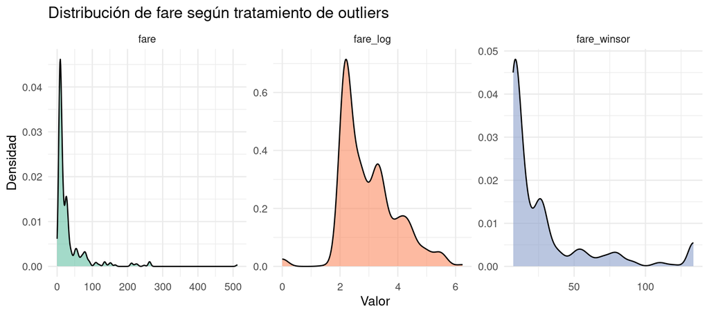

```r
titanic_limpio |>
  select(fare, fare_winsor, fare_log) |>
  pivot_longer(everything(), names_to = "version", values_to = "valor") |>
  ggplot(aes(x = valor, fill = version)) +
  geom_density(alpha = 0.6) +
  facet_wrap(~ version, scales = "free") +
  scale_fill_brewer(palette = "Set2", guide = "none") +
  labs(title = "Distribución de fare según tratamiento de outliers",
       x = "Valor", y = "Densidad") +
  theme_minimal(base_size = 12)
```

# 5. Transformación de variables

## 5.1 Conversión de tipos

Un problema frecuente: variables numéricas leídas como carácter, o factores almacenados como enteros.

```r
glimpse(adult[, 1:7])
```

```
## Rows: 32,561
## Columns: 7
## $ age            <dbl> 90, 82, 66, 54, 41, 34, 38, 74, 68, 41, 45, 38, 52, 32,…
## $ workclass      <chr> "?", "Private", "?", "Private", "Private", "Private", "…
## $ fnlwgt         <dbl> 77053, 132870, 186061, 140359, 264663, 216864, 150601, …
## $ education      <chr> "HS-grad", "HS-grad", "Some-college", "7th-8th", "Some-…
## $ education.num  <dbl> 9, 9, 10, 4, 10, 9, 6, 16, 9, 10, 16, 15, 13, 14, 16, 1…
## $ marital.status <chr> "Widowed", "Widowed", "Widowed", "Divorced", "Separated…
## $ occupation     <chr> "?", "Exec-managerial", "?", "Machine-op-inspct", "Prof…
```

El dataset `adult` usa `"?"` como código para datos faltantes — un patrón muy común en datos del mundo real:

```r
adult_limpio <- adult |>
  mutate(
    across(where(is.character),
           ~ na_if(str_trim(.x), "?"))
  )

cat("NA en workclass antes :", sum(adult$workclass == "?", na.rm = TRUE), "\n")
```

```
## NA en workclass antes : 1836
```

```r
cat("NA en workclass después:", sum(is.na(adult_limpio$workclass)), "\n")
```

```
## NA en workclass después: 1836
```

```r
adult_limpio <- adult_limpio |>
  mutate(
    income = factor(income, levels = c("<=50K", ">50K")),
    education = factor(
      education,
      levels = c("Preschool","1st-4th","5th-6th","7th-8th","9th",
                 "10th","11th","12th","HS-grad","Some-college",
                 "Assoc-voc","Assoc-acdm","Bachelors","Prof-school",
                 "Masters","Doctorate"),
      ordered = TRUE
    )
  )

cat("Niveles de income   :", levels(adult_limpio$income), "\n")
```

```
## Niveles de income   : <=50K >50K
```

```r
cat("¿Education ordenada?:", is.ordered(adult_limpio$education), "\n")
```

```
## ¿Education ordenada?: TRUE
```

## 5.2 Discretización: de continua a categórica

`cut` divide un vector numérico en intervalos. Útil para análisis por grupos de edad, tramos de precio, etc.:

```r
titanic_limpio <- titanic_limpio |>
  mutate(
    grupo_edad = cut(
      age_imp,
      breaks = c(0, 12, 18, 35, 60, Inf),
      labels = c("Niño", "Adolescente", "Adulto joven", "Adulto", "Mayor"),
      right  = TRUE,
      include.lowest = TRUE
    )
  )

titanic_limpio |>
  count(grupo_edad) |>
  mutate(pct = round(n / sum(n) * 100, 1)) |>
  mostrar_tabla(caption = "Distribución por grupo de edad")
```

Distribución por grupo de edad

| grupo_edad | n | pct |
| --- | --- | --- |
| Niño | 94 | 7.2 |
| Adolescente | 99 | 7.6 |
| Adulto joven | 794 | 60.7 |
| Adulto | 289 | 22.1 |
| Mayor | 33 | 2.5 |

```r
titanic_limpio <- titanic_limpio |>
  mutate(
    cuartil_tarifa = ntile(fare, 4) |>
      factor(labels = c("Q1 (bajo)", "Q2", "Q3", "Q4 (alto)"))
  )

titanic_limpio |>
  group_by(cuartil_tarifa) |>
  summarise(
    n            = n(),
    fare_min     = round(min(fare, na.rm = TRUE), 1),
    fare_max     = round(max(fare, na.rm = TRUE), 1),
    tasa_superv  = round(mean(survived, na.rm = TRUE), 3),
    .groups = "drop"
  ) |>
  mostrar_tabla(caption = "Supervivencia por cuartil de tarifa")
```

Supervivencia por cuartil de tarifa

| cuartil_tarifa | n | fare_min | fare_max | tasa_superv |
| --- | --- | --- | --- | --- |
| Q1 (bajo) | 327 | 0.0 | 7.9 | 0.291 |
| Q2 | 327 | 7.9 | 14.5 | 0.361 |
| Q3 | 327 | 14.5 | 31.3 | 0.462 |
| Q4 (alto) | 327 | 31.3 | 512.3 | 0.541 |
| NA | 1 | Inf | -Inf | 0.000 |

## 5.3 Recodificación con `case_when` y `fct_lump`

```r
titanic_limpio <- titanic_limpio |>
  mutate(
    titulo_grupo = case_when(
      titulo %in% c("Mr")               ~ "Mr",
      titulo %in% c("Mrs", "Mme")       ~ "Mrs",
      titulo %in% c("Miss", "Ms","Mlle")~ "Miss",
      titulo == "Master"                ~ "Master",
      TRUE                              ~ "Otro"
    ),
    titulo_grupo = fct_infreq(titulo_grupo)
  )

titanic_limpio |>
  count(titulo_grupo, sort = TRUE) |>
  mostrar_tabla(caption = "Distribución de títulos recodificados")
```

Distribución de títulos recodificados

| titulo_grupo | n |
| --- | --- |
| Mr | 757 |
| Miss | 264 |
| Mrs | 198 |
| Master | 61 |
| Otro | 29 |

## 5.4 Codificación de variables categóricas

Los modelos de ML requieren **números**, no texto. Hay dos enfoques principales:

### Label encoding (ordinal implícito)

```r
titanic_limpio <- titanic_limpio |>
  mutate(
    sex_num       = as.integer(factor(sex)),
    embarked_num  = as.integer(factor(embarked_imp))
  )

titanic_limpio |>
  distinct(sex, sex_num, embarked_imp, embarked_num) |>
  arrange(sex_num) |>
  mostrar_tabla(caption = "Label encoding de variables categóricas")
```

Label encoding de variables categóricas

| sex | sex_num | embarked_imp | embarked_num |
| --- | --- | --- | --- |
| female | 1 | S | 3 |
| female | 1 | C | 1 |
| female | 1 | Q | 2 |
| male | 2 | S | 3 |
| male | 2 | C | 1 |
| male | 2 | Q | 2 |

> **Advertencia:** label encoding introduce una ordenación artificial (2 > 1) que puede confundir al modelo. Solo es apropiado para variables **ordinales** o árboles de decisión.

### One-hot encoding (dummies)

```r
one_hot <- model.matrix(~ embarked_imp - 1, data = titanic_limpio) |>
  as.data.frame() |>
  rename_with(~ str_replace(.x, "embarked_imp", "emb_")) |>
  bind_cols(titanic_limpio |> select(id))

head(one_hot, 6) |> mostrar_tabla(caption = "One-hot encoding de embarked")
```

One-hot encoding de embarked

| emb_C | emb_Q | emb_S | id |
| --- | --- | --- | --- |
| 0 | 0 | 1 | 0 |
| 0 | 0 | 1 | 1 |
| 0 | 0 | 1 | 2 |
| 0 | 0 | 1 | 3 |
| 0 | 0 | 1 | 4 |
| 1 | 0 | 0 | 5 |

# 6. Normalización y estandarización

Las variables en escalas distintas causan problemas en modelos basados en distancias (KNN, SVM) y en gradientes (regresión logística, redes neuronales).

## 6.1 Min-Max scaling (normalización al rango [0, 1])

$$x' = \frac{x - x_{\min}}{x_{\max} - x_{\min}}$$

```r
min_max <- function(x) {
  (x - min(x, na.rm = TRUE)) / (max(x, na.rm = TRUE) - min(x, na.rm = TRUE))
}

moviles_norm <- moviles |>
  mutate(
    across(c(ram, battery_power, int_memory, px_height, px_width),
           list(mm = min_max),
           .names = "{.col}_{.fn}")
  )

moviles_norm |>
  select(ram, ram_mm, battery_power, battery_power_mm) |>
  slice(1:5) |>
  mostrar_tabla(caption = "Min-Max scaling — primeras 5 filas")
```

Min-Max scaling — primeras 5 filas

| ram | ram_mm | battery_power | battery_power_mm |
| --- | --- | --- | --- |
| 2549 | 0.6127739 | 842 | 0.2281521 |
| 2631 | 0.6346873 | 1021 | 0.3475650 |
| 2603 | 0.6272047 | 563 | 0.0420280 |
| 2769 | 0.6715660 | 615 | 0.0767178 |
| 1411 | 0.3086585 | 1821 | 0.8812542 |

**Propiedad clave:** después del Min-Max, todas las variables tienen rango `[0, 1]`.

```r
moviles_norm |>
  select(ends_with("_mm")) |>
  map_df(~ tibble(minimo = min(.x, na.rm = TRUE),
                  maximo = max(.x, na.rm = TRUE)),
         .id = "variable") |>
  mostrar_tabla(caption = "Verificación: rango [0,1] para todas las variables")
```

Verificación: rango [0,1] para todas las variables

| variable | minimo | maximo |
| --- | --- | --- |
| ram_mm | 0 | 1 |
| battery_power_mm | 0 | 1 |
| int_memory_mm | 0 | 1 |
| px_height_mm | 0 | 1 |
| px_width_mm | 0 | 1 |

## 6.2 Z-score estandarización (media 0, desviación 1)

$$x' = \frac{x - \bar{x}}{s}$$

```r
estandarizar <- function(x) (x - mean(x, na.rm = TRUE)) / sd(x, na.rm = TRUE)

moviles_std <- moviles |>
  mutate(
    across(c(ram, battery_power, int_memory, px_height, px_width),
           list(std = estandarizar),
           .names = "{.col}_{.fn}")
  )

moviles_std |>
  select(ends_with("_std")) |>
  map_df(~ tibble(media = round(mean(.x, na.rm = TRUE), 4),
                  sd    = round(sd(.x,   na.rm = TRUE), 4)),
         .id = "variable") |>
  mostrar_tabla(caption = "Verificación: media≈0 y sd=1 para cada variable")
```

Verificación: media≈0 y sd=1 para cada variable

| variable | media | sd |
| --- | --- | --- |
| ram_std | 0 | 1 |
| battery_power_std | 0 | 1 |
| int_memory_std | 0 | 1 |
| px_height_std | 0 | 1 |
| px_width_std | 0 | 1 |

## 6.3 Normalización L2 (norma unitaria por fila)

$$\mathbf{x}' = \frac{\mathbf{x}}{\|\mathbf{x}\|_2}$$

Usada principalmente en modelos de texto y recomendación:

```r
normalizar_l2 <- function(df, cols) {
  mat <- as.matrix(df[, cols])
  norma <- sqrt(rowSums(mat^2))
  as.data.frame(mat / norma)
}

cols_num <- c("ram", "battery_power", "int_memory", "px_height", "px_width")

moviles_l2 <- normalizar_l2(moviles, cols_num)
normas_fila <- sqrt(rowSums(moviles_l2^2))

cat("Norma L2 de las primeras 5 filas (deben ser ≈ 1):\n")
```

[output not shown]

```r
round(head(normas_fila), 6)
```

```
## [1] 1 1 1 1 1 1
```

## 6.4 Comparativa visual: escalas originales vs. normalizadas

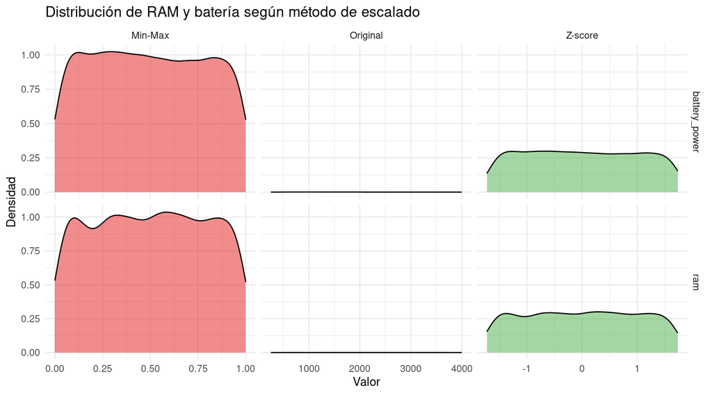

```r
bind_rows(
  moviles |>
    select(ram, battery_power) |>
    mutate(escala = "Original"),
  moviles_norm |>
    select(ram = ram_mm, battery_power = battery_power_mm) |>
    mutate(escala = "Min-Max"),
  moviles_std |>
    select(ram = ram_std, battery_power = battery_power_std) |>
    mutate(escala = "Z-score")
) |>
  pivot_longer(c(ram, battery_power), names_to = "variable", values_to = "valor") |>
  ggplot(aes(x = valor, fill = escala)) +
  geom_density(alpha = 0.5) +
  facet_grid(variable ~ escala, scales = "free") +
  scale_fill_brewer(palette = "Set1", guide = "none") +
  labs(title = "Distribución de RAM y batería según método de escalado",
       x = "Valor", y = "Densidad") +
  theme_minimal(base_size = 11)
```

> **¿Cuál usar?** - **Min-Max:** cuando conoces los límites del rango y el algoritmo necesita valores en [0,1] (e.g., redes neuronales sigmoideas). - **Z-score:** cuando la distribución es aproximadamente normal o quieres preservar outliers como información (e.g., SVM, PCA). - **L2:** cuando el módulo del vector importa, no su escala absoluta (e.g., similitud coseno en NLP).

# 7. Pipelines con `purrr`

`purrr` permite aplicar transformaciones **sobre múltiples datasets o columnas** de forma funcional, sin bucles explícitos.

## 7.1 `map` y variantes

```r
datasets <- list(titanic = titanic, adult = adult, moviles = moviles)

# Contar NA por dataset
datasets |>
  map_df(~ tibble(total_na = sum(is.na(.x))), .id = "dataset") |>
  mostrar_tabla(caption = "Total de NA por dataset")
```

Total de NA por dataset

| dataset | total_na |
| --- | --- |
| titanic | 3855 |
| adult | 0 |
| moviles | 0 |

```r
# Dimensiones de cada dataset
datasets |>
  map_df(~ tibble(filas = nrow(.x), columnas = ncol(.x)),
         .id = "dataset") |>
  mostrar_tabla(caption = "Dimensiones de cada dataset")
```

Dimensiones de cada dataset

| dataset | filas | columnas |
| --- | --- | --- |
| titanic | 1309 | 16 |
| adult | 32561 | 15 |
| moviles | 3000 | 21 |

## 7.2 `map` para limpiar múltiples columnas

```r
cols_numericas <- moviles |>
  select(where(is.numeric)) |>
  names()

estadisticas <- moviles |>
  select(all_of(cols_numericas[1:6])) |>
  map_df(~ tibble(
    media    = round(mean(.x, na.rm = TRUE), 2),
    mediana  = round(median(.x, na.rm = TRUE), 2),
    sd       = round(sd(.x, na.rm = TRUE), 2),
    asimetria = round((mean(.x, na.rm = TRUE) - median(.x, na.rm = TRUE)) /
                        sd(.x, na.rm = TRUE), 3)
  ), .id = "variable")

mostrar_tabla(estadisticas, caption = "Estadísticas básicas — 6 variables de móviles")
```

Estadísticas básicas — 6 variables de móviles

| variable | media | mediana | sd | asimetria |
| --- | --- | --- | --- | --- |
| battery_power | 1241.85 | 1232.0 | 437.06 | 0.023 |
| blue | 0.50 | 1.0 | 0.50 | -0.996 |
| clock_speed | 1.53 | 1.5 | 0.82 | 0.035 |
| dual_sim | 0.51 | 1.0 | 0.50 | -0.976 |
| fc | 4.40 | 3.0 | 4.38 | 0.320 |
| four_g | 0.51 | 1.0 | 0.50 | -0.980 |

## 7.3 `walk` para efectos secundarios (guardar archivos, imprimir)

```r
# Guardar cada dataset limpio como CSV
list(
  titanic_limpio = titanic_limpio,
  adult_limpio   = adult_limpio
) |>
  iwalk(~ write_csv(.x, paste0("../../data/", .y, ".csv")))
```

## 7.4 Pipeline completo de limpieza con funciones

La mejor práctica es encapsular cada paso de limpieza en una función con nombre descriptivo:

```r
eliminar_cols_alta_na  <- function(df, umbral = 0.50)
  df |> select(where(~ mean(is.na(.x)) <= umbral))

imputar_numericas      <- function(df)
  df |> mutate(across(where(is.numeric), ~ if_else(is.na(.x), median(.x, na.rm = TRUE), .x)))

imputar_categoricas    <- function(df) {
  moda <- function(x) { ux <- unique(x[!is.na(x)]); ux[which.max(tabulate(match(x, ux)))] }
  df |> mutate(across(where(is.character), ~ if_else(is.na(.x), moda(.x), .x)))
}

aplicar_minmax         <- function(df)
  df |> mutate(across(where(is.numeric), ~ (.x - min(.x, na.rm=TRUE)) / (max(.x, na.rm=TRUE) - min(.x, na.rm=TRUE))))

titanic_pipeline <- titanic |>
  eliminar_cols_alta_na() |>
  imputar_numericas() |>
  imputar_categoricas()

cat("Filas con NA después del pipeline:", sum(!complete.cases(titanic_pipeline)), "\n")
```

```
## Filas con NA después del pipeline: 0
```

```r
cat("Dimensiones finales:", nrow(titanic_pipeline), "×", ncol(titanic_pipeline), "\n")
```

```
## Dimensiones finales: 1309 × 13
```

# 8. Equivalente en Python

```python
import pandas as pd
import numpy as np
from sklearn.preprocessing import MinMaxScaler, StandardScaler, Normalizer

# ── Carga ──────────────────────────────────────────────────────────
titanic = pd.read_csv("../../data/titanic.csv")
moviles = pd.read_csv("../../data/mobile_data.csv")

# ── 1. Diagnóstico de NA ───────────────────────────────────────────
na_pct = titanic.isna().mean().sort_values(ascending=False)
print(na_pct[na_pct > 0].round(3))

# ── 2. Eliminar columnas con > 50% NA ─────────────────────────────
titanic_limpio = titanic.loc[:, titanic.isna().mean() <= 0.50]

# ── 3. Imputar numérica con mediana ───────────────────────────────
titanic_limpio["age"] = titanic_limpio["age"].fillna(
    titanic_limpio["age"].median()
)

# ── 4. Imputar categórica con moda ────────────────────────────────
titanic_limpio["embarked"] = titanic_limpio["embarked"].fillna(
    titanic_limpio["embarked"].mode()[0]
)

# ── 5. Reemplazar "?" por NaN (adult dataset) ─────────────────────
adult = pd.read_csv("../../data/adult.csv")
adult.replace("?", np.nan, inplace=True)

# ── 6. Discretización ─────────────────────────────────────────────
titanic_limpio["grupo_edad"] = pd.cut(
    titanic_limpio["age"],
    bins=[0, 12, 18, 35, 60, np.inf],
    labels=["Niño", "Adolescente", "Adulto joven", "Adulto", "Mayor"]
)

# ── 7. One-hot encoding ───────────────────────────────────────────
dummies = pd.get_dummies(titanic_limpio["embarked"], prefix="emb")
titanic_limpio = pd.concat([titanic_limpio, dummies], axis=1)

# ── 8. Normalización con scikit-learn ─────────────────────────────
cols_num = ["ram", "battery_power", "int_memory", "px_height", "px_width"]
X = moviles[cols_num].dropna()

# Min-Max
scaler_mm = MinMaxScaler()
X_mm = pd.DataFrame(scaler_mm.fit_transform(X), columns=[c + "_mm" for c in cols_num])

# Z-score
scaler_std = StandardScaler()
X_std = pd.DataFrame(scaler_std.fit_transform(X), columns=[c + "_std" for c in cols_num])

# L2
scaler_l2 = Normalizer(norm="l2")
X_l2 = pd.DataFrame(scaler_l2.fit_transform(X), columns=[c + "_l2" for c in cols_num])

print(X_mm.describe().round(3))
print(X_std.describe().round(3))

# ── 9. Detección de outliers (IQR) ────────────────────────────────
def outliers_iqr(serie, k=1.5):
    q1, q3 = serie.quantile([0.25, 0.75])
    iqr = q3 - q1
    return (serie < q1 - k * iqr) | (serie > q3 + k * iqr)

mask_fare = outliers_iqr(titanic_limpio["fare"])
print(f"Outliers en fare: {mask_fare.sum()}")

# ── 10. Pipeline con sklearn ──────────────────────────────────────
from sklearn.pipeline import Pipeline
from sklearn.impute import SimpleImputer
from sklearn.compose import ColumnTransformer

num_cols = ["age", "fare", "sibsp", "parch"]
cat_cols = ["sex", "embarked"]

preprocessor = ColumnTransformer([
    ("num", Pipeline([
        ("imputer", SimpleImputer(strategy="median")),
        ("scaler",  StandardScaler())
    ]), num_cols),
    ("cat", Pipeline([
        ("imputer", SimpleImputer(strategy="most_frequent")),
        ("ohe",     pd.get_dummies)   # o OneHotEncoder()
    ]), cat_cols)
])
```

### Tabla comparativa R vs. Python

| Tarea | R (tidyverse + purrr) | Python (pandas + sklearn) |
| --- | --- | --- |
| Diagnóstico NA | `map_df(~ sum(is.na(.x)))` | `df.isna().mean()` |
| Eliminar cols con NA | `select(where(~ mean(is.na(.x)) <= u))` | `df.loc[:, df.isna().mean() <= u]` |
| Imputar mediana | `mutate(x = if_else(is.na(x), median(x, na.rm=T), x))` | `df["x"].fillna(df["x"].median())` |
| Imputar por grupo | `group_by() \|> mutate(...)` | `groupby().transform("median")` |
| Reemplazar “?” | `na_if(str_trim(x), "?")` | `df.replace("?", np.nan)` |
| Discretizar | `cut(x, breaks, labels)` | `pd.cut(x, bins, labels)` |
| One-hot | `pivot_wider(names_from=...)` | `pd.get_dummies(df, columns=...)` |
| Min-Max | función manual + `mutate(across(...))` | `MinMaxScaler().fit_transform(X)` |
| Z-score | función manual + `mutate(across(...))` | `StandardScaler().fit_transform(X)` |
| Pipeline funcional | `función1() \|> función2() \|> ...` | `sklearn.pipeline.Pipeline([...])` |

# 9. Ejercicios prácticos

## Ejercicio 1

Usando el dataset `house_prices.csv`:

1. Identifica las 5 columnas con mayor porcentaje de NA. ¿Cuáles eliminarías y cuáles imputarías? Justifica.
2. Imputa las columnas numéricas con NA usando la **mediana** y las categóricas con la **moda**. ¿Cuántas filas quedan completas (sin ningún NA) después?
3. Crea una variable `antiguedad` = `2024 - YearBuilt`. Discretízala en 4 grupos con `cut` usando los cuartiles como puntos de corte.

## Ejercicio 2

Usando `titanic.csv`:

1. Aplica el criterio IQR para detectar outliers en `fare`. ¿Qué porcentaje de pasajeros son outliers?
2. Compara tres versiones de `fare`: original, winsorizada al percentil 5–95, y transformación `log(1 + fare)`. Grafica sus distribuciones.
3. Crea un nuevo dataset donde `fare` esté winsorizada y `age` esté imputada con la mediana por grupo de `pclass`. Verifica que no queden NA en esas columnas.

## Ejercicio 3

Usando `mobile_data.csv`:

1. Aplica Min-Max y Z-score a las variables `ram`, `battery_power` y `px_height`. Verifica propiedades: ¿el rango de Min-Max es [0,1]? ¿La media de Z-score es 0?
2. Grafica un scatter plot de `ram` vs. `battery_power` para las tres versiones (original, Min-Max, Z-score). ¿Cambia la **forma** de la nube de puntos?
3. ¿En qué situación el Min-Max da resultados problemáticos? Genera un ejemplo sintético con un outlier extremo y muestra el efecto.

## Ejercicio 4

Construye un pipeline funcional que procese el dataset `adult.csv` end-to-end:

1. Reemplaza `"?"` por `NA` en todas las columnas character.
2. Elimina columnas con > 10 % de NA.
3. Imputa las columnas numéricas con la mediana y las categóricas con la moda.
4. Codifica `income` como variable binaria: `>50K` = 1, `<=50K` = 0.
5. Aplica Z-score a todas las columnas numéricas.
6. Usa `purrr::map_df` para generar una tabla resumen con media y sd de cada columna numérica antes y después del Z-score. ¿Qué observas?